# **Bigquery - Chicago Crime**

## **About the dataset**

This dataset reflects reported incidents of crime (with the exception of murders where data exists for each victim) that occurred in the City of Chicago from 2001 to present, minus the most recent seven days. Data is extracted from the Chicago Police Department's CLEAR (Citizen Law Enforcement Analysis and Reporting) system. In order to protect the privacy of crime victims, addresses are shown at the block level only and specific locations are not identified. This data includes unverified reports supplied to the Police Department. The preliminary crime classifications may be changed at a later date based upon additional investigation and there is always the possibility of mechanical or human error. Therefore, the Chicago Police Department does not guarantee (either expressed or implied) the accuracy, completeness, timeliness, or correct sequencing of the information and the information should not be used for comparison purposes over time.

### **Setup**

**Check and install the dependencies**

```python
base_url='https://raw.githubusercontent.com/K14aNB/'
```

```python
repo_name='bigquery-chicago-crime'
```

```python
nb_name='Bigquery-Chicago-Crime'
```

```python
!curl -sSL {base_url}{repo_name}'/main/requirements.txt'
```

```
pandas==2.2.2
matplotlib
seaborn
PyYAML
db-dtypes
download_kaggle_dataset @ git+https://github.com/K14aNB/download-kaggle-dataset.git@main
gcloud_bigquery_setup @ git+https://github.com/K14aNB/gcloud-bigquery-setup.git@main
env_setup @ git+https://github.com/K14aNB/setup-notebook-environment.git@main
```

```python
# Run this command in terminal before running this notebook as .py script
# Installs dependencies from requirements.txt present in the repo
%%capture
!pip install -r {base_url}{repo_name}'/main/requirements.txt'
```

**Import the libraries**

```python
from google.cloud import bigquery
import numpy as np
import pandas as pd
import matplotlib.pyplot as plt
import seaborn as sns
import db_dtypes
import env_setup
import os
```

**Environment Setup**

```python
client,datasets=env_setup.setup(repo_name=repo_name,nb_name=nb_name)
```

```
Found the repo
MLFlow config is not specified in config.yaml
```

[output not shown]

[output not shown]

**Tables**

```python
for dataset in datasets:
    tables_list=list(client.list_tables(dataset))
    for table in tables_list:
        print(dataset.table(table.table_id))
```

```
bigquery-public-data.chicago_crime.crime
```

```python
crime=client.get_table('bigquery-public-data.chicago_crime.crime')
```

### **Exploratory Data Analysis**

```python
# Set a limit on number of bytes that can be billed per query
max_bytes_limit_per_query=3*10**8
```

**Schema of `crime` table**

```python
crime.schema
```

```
[SchemaField('unique_key', 'INTEGER', 'REQUIRED', None, None, (), None),
 SchemaField('case_number', 'STRING', 'NULLABLE', None, None, (), None),
 SchemaField('date', 'TIMESTAMP', 'NULLABLE', None, None, (), None),
 SchemaField('block', 'STRING', 'NULLABLE', None, None, (), None),
 SchemaField('iucr', 'STRING', 'NULLABLE', None, None, (), None),
 SchemaField('primary_type', 'STRING', 'NULLABLE', None, None, (), None),
 SchemaField('description', 'STRING', 'NULLABLE', None, None, (), None),
 SchemaField('location_description', 'STRING', 'NULLABLE', None, None, (), None),
 SchemaField('arrest', 'BOOLEAN', 'NULLABLE', None, None, (), None),
 SchemaField('domestic', 'BOOLEAN', 'NULLABLE', None, None, (), None),
 SchemaField('beat', 'INTEGER', 'NULLABLE', None, None, (), None),
 SchemaField('district', 'INTEGER', 'NULLABLE', None, None, (), None),
 SchemaField('ward', 'INTEGER', 'NULLABLE', None, None, (), None),
 SchemaField('community_area', 'INTEGER', 'NULLABLE', None, None, (), None),
 SchemaField('fbi_code', 'STRING', 'NULLABLE', None, None, (), None),
 SchemaField('x_coordinate', 'FLOAT', 'NULLABLE', None, None, (), None),
 SchemaField('y_coordinate', 'FLOAT', 'NULLABLE', None, None, (), None),
 SchemaField('year', 'INTEGER', 'NULLABLE', None, None, (), None),
 SchemaField('updated_on', 'TIMESTAMP', 'NULLABLE', None, None, (), None),
 SchemaField('latitude', 'FLOAT', 'NULLABLE', None, None, (), None),
 SchemaField('longitude', 'FLOAT', 'NULLABLE', None, None, (), None),
 SchemaField('location', 'STRING', 'NULLABLE', None, None, (), None)]
```

**List first 5 records from `crime` table**

```python
crime_first_five=client.list_rows(crime,max_results=5).to_dataframe()
```

```python
crime_first_five
```

|  | unique_key | case_number | date | block | iucr | primary_type | description | location_description | arrest | domestic | ... | ward | community_area | fbi_code | x_coordinate | y_coordinate | year | updated_on | latitude | longitude | location |
| --- | --- | --- | --- | --- | --- | --- | --- | --- | --- | --- | --- | --- | --- | --- | --- | --- | --- | --- | --- | --- | --- |
| 0 | 13306418 | JG539387 | 2023-12-12 02:15:00+00:00 | 001XX N STATE ST | 0313 | ROBBERY | ARMED - OTHER DANGEROUS WEAPON | DEPARTMENT STORE | False | False | ... | 34 | 32 | 03 | 1176352.0 | 1900918.0 | 2023 | 2023-12-20 03:41:19+00:00 | 41.883475 | -87.627877 | (41.883475491, -87.627876969) |
| 1 | 1747464 | G555411 | 2001-09-16 01:30:00+00:00 | 004XX W RANDOLPH ST | 0313 | ROBBERY | ARMED: OTHER DANGEROUS WEAPON | STREET | False | False | ... | <NA> | <NA> | 03 | 1173286.0 | 1901207.0 | 2001 | 2015-08-17 03:03:40+00:00 | 41.884337 | -87.639127 | (41.884337134, -87.639126855) |
| 2 | 11936430 | JC565215 | 2019-12-28 09:30:00+00:00 | 001XX N STATE ST | 031A | ROBBERY | ARMED: HANDGUN | STREET | False | False | ... | 42 | 32 | 03 | 1176332.0 | 1901600.0 | 2019 | 2020-01-04 03:40:55+00:00 | 41.885347 | -87.627930 | (41.885347387, -87.627929824) |
| 3 | 13149899 | JG352235 | 2023-07-22 11:56:00+00:00 | 001XX N STATE ST | 031A | ROBBERY | ARMED - HANDGUN | SIDEWALK | False | False | ... | 42 | 32 | 03 | 1176338.0 | 1901346.0 | 2023 | 2023-08-19 03:40:26+00:00 | 41.884650 | -87.627915 | (41.884650262, -87.627915459) |
| 4 | 5525318 | HN339025 | 2007-05-12 10:08:00+00:00 | 005XX W LAKE ST | 031A | ROBBERY | ARMED: HANDGUN | STREET | True | False | ... | 42 | 28 | 03 | 1172491.0 | 1901698.0 | 2007 | 2018-02-28 03:56:25+00:00 | 41.885702 | -87.642032 | (41.885702079, -87.642031644) |

5 rows × 22 columns

```python
crime_first_five.info()
```

```
<class 'pandas.core.frame.DataFrame'>
RangeIndex: 5 entries, 0 to 4
Data columns (total 22 columns):
 #   Column                Non-Null Count  Dtype
---  ------                --------------  -----
 0   unique_key            5 non-null      Int64
 1   case_number           5 non-null      object
 2   date                  5 non-null      datetime64[us, UTC]
 3   block                 5 non-null      object
 4   iucr                  5 non-null      object
 5   primary_type          5 non-null      object
 6   description           5 non-null      object
 7   location_description  5 non-null      object
 8   arrest                5 non-null      boolean
 9   domestic              5 non-null      boolean
 10  beat                  5 non-null      Int64
 11  district              5 non-null      Int64
 12  ward                  4 non-null      Int64
 13  community_area        4 non-null      Int64
 14  fbi_code              5 non-null      object
 15  x_coordinate          5 non-null      float64
 16  y_coordinate          5 non-null      float64
 17  year                  5 non-null      Int64
 18  updated_on            5 non-null      datetime64[us, UTC]
 19  latitude              5 non-null      float64
 20  longitude             5 non-null      float64
 21  location              5 non-null      object
dtypes: Int64(6), boolean(2), datetime64[us, UTC](2), float64(4), object(8)
memory usage: 982.0+ bytes
```

**Columns which have `TIMESTAMP` data**

```python
timestamp_cols=[field.name for field in crime.schema if field.field_type=='TIMESTAMP']
print(timestamp_cols)
```

```
['date', 'updated_on']
```

**Types of Crimes committed**

```python
crime_type_query='''
                 SELECT primary_type,COUNT(1) AS count_of_crime_committed
                 FROM bigquery-public-data.chicago_crime.crime
                 GROUP BY primary_type
                 ORDER BY count_of_crime_committed DESC
                 '''
crime_type_query_run=False
```

```python
# Dry Run
crime_type_query_config_dr=bigquery.QueryJobConfig(dry_run=True,use_query_cache=False)
crime_type_job_dr=client.query(crime_type_query,job_config=crime_type_query_config_dr)
print(f'Total bytes processed={crime_type_job_dr.total_bytes_processed}')
```

```
Total bytes processed=97394772
```

```python
# Actual Run
if crime_type_job_dr.total_bytes_processed<=max_bytes_limit_per_query:
    crime_type_query_config=bigquery.QueryJobConfig(maximum_bytes_billed=crime_type_job_dr.total_bytes_processed+10**6)
    crime_type_job=client.query(crime_type_query,job_config=crime_type_query_config)
    crime_type_results=crime_type_job.to_dataframe()
    crime_type_query_run=True
```

```python
crime_type_results
```

|  | primary_type | count_of_crime_committed |
| --- | --- | --- |
| 0 | THEFT | 1705937 |
| 1 | BATTERY | 1472853 |
| 2 | CRIMINAL DAMAGE | 919883 |
| 3 | NARCOTICS | 753776 |
| 4 | ASSAULT | 532812 |
| 5 | OTHER OFFENSE | 501670 |
| 6 | BURGLARY | 432592 |
| 7 | MOTOR VEHICLE THEFT | 404380 |
| 8 | DECEPTIVE PRACTICE | 364653 |
| 9 | ROBBERY | 304258 |
| 10 | CRIMINAL TRESPASS | 219459 |
| 11 | WEAPONS VIOLATION | 115637 |
| 12 | PROSTITUTION | 70052 |
| 13 | OFFENSE INVOLVING CHILDREN | 57960 |
| 14 | PUBLIC PEACE VIOLATION | 53288 |
| 15 | SEX OFFENSE | 32304 |
| 16 | CRIM SEXUAL ASSAULT | 27482 |
| 17 | INTERFERENCE WITH PUBLIC OFFICER | 19052 |
| 18 | LIQUOR LAW VIOLATION | 15113 |
| 19 | GAMBLING | 14638 |
| 20 | ARSON | 13821 |
| 21 | HOMICIDE | 13215 |
| 22 | CRIMINAL SEXUAL ASSAULT | 8727 |
| 23 | KIDNAPPING | 7360 |
| 24 | STALKING | 5350 |
| 25 | INTIMIDATION | 4887 |
| 26 | CONCEALED CARRY LICENSE VIOLATION | 1286 |
| 27 | OBSCENITY | 873 |
| 28 | PUBLIC INDECENCY | 203 |
| 29 | NON-CRIMINAL | 185 |
| 30 | OTHER NARCOTIC VIOLATION | 150 |
| 31 | HUMAN TRAFFICKING | 107 |
| 32 | NON - CRIMINAL | 38 |
| 33 | RITUALISM | 24 |
| 34 | NON-CRIMINAL (SUBJECT SPECIFIED) | 9 |
| 35 | DOMESTIC VIOLENCE | 1 |

**Unique `location_description` where crimes were committed**

```python
crime_locations_query='''
                      SELECT DISTINCT location_description
                      FROM bigquery-public-data.chicago_crime.crime
                      '''
crime_locations_query_run=False
```

```python
# Dry Run
crime_locations_query_config_dr=bigquery.QueryJobConfig(dry_run=True,use_query_cache=False)
crime_locations_job_dr=client.query(crime_locations_query,job_config=crime_locations_query_config_dr)
print(f'Total bytes processed={crime_locations_job_dr.total_bytes_processed}')
```

```
Total bytes processed=106653698
```

```python
# Actual Run
if crime_locations_job_dr.total_bytes_processed<=max_bytes_limit_per_query:
    crime_locations_query_config=bigquery.QueryJobConfig(maximum_bytes_billed=crime_locations_job_dr.total_bytes_processed+10**6)
    crime_locations_job=client.query(crime_locations_query,job_config=crime_locations_query_config)
    crime_locations_results=crime_locations_job.to_dataframe()
    crime_locations_query_run=True
```

```python
crime_locations_results
```

|  | location_description |
| --- | --- |
| 0 | GROCERY FOOD STORE |
| 1 | HOTEL/MOTEL |
| 2 | BRIDGE |
| 3 | MEDICAL/DENTAL OFFICE |
| 4 | PARKING LOT/GARAGE(NON.RESID.) |
| ... | ... |
| 213 | BARBER SHOP/BEAUTY SALON |
| 214 | KENNEL |
| 215 | HORSE STABLE |
| 216 | BANQUET HALL |
| 217 | ROOF |

218 rows × 1 columns

**What types of crime took place in `GOVERNMENT BUILDING/PROPERTY`?**

```python
gov_bldg_crime_types_query='''
                           SELECT primary_type,COUNT(1) AS counts_of_crime
                           FROM bigquery-public-data.chicago_crime.crime
                           WHERE location_description="GOVERNMENT BUILDING/PROPERTY"
                           GROUP BY primary_type
                           ORDER BY counts_of_crime DESC
                           '''
gov_bldg_crime_types_query_run=False
```

```python
# Dry Run
gov_bldg_crime_types_query_config_dr=bigquery.QueryJobConfig(dry_run=True,use_query_cache=False)
gov_bldg_crime_types_job_dr=client.query(gov_bldg_crime_types_query,job_config=gov_bldg_crime_types_query_config_dr)
print(f'Total bytes processed={gov_bldg_crime_types_job_dr.total_bytes_processed}')
```

```
Total bytes processed=204048470
```

```python
# Actual Run
if gov_bldg_crime_types_job_dr.total_bytes_processed<=max_bytes_limit_per_query:
    gov_bldg_crime_types_query_config=bigquery.QueryJobConfig(maximum_bytes_billed=gov_bldg_crime_types_job_dr.total_bytes_processed+10**6)
    gov_bldg_crime_types_job=client.query(gov_bldg_crime_types_query,job_config=gov_bldg_crime_types_query_config)
    gov_bldg_crime_types_results=gov_bldg_crime_types_job.to_dataframe()
    gov_bldg_crime_types_query_run=True
```

```python
gov_bldg_crime_types_results
```

|  | primary_type | counts_of_crime |
| --- | --- | --- |
| 0 | THEFT | 2929 |
| 1 | ASSAULT | 2145 |
| 2 | BATTERY | 1845 |
| 3 | NARCOTICS | 1642 |
| 4 | OTHER OFFENSE | 1563 |
| 5 | CRIMINAL DAMAGE | 1345 |
| 6 | CRIMINAL TRESPASS | 958 |
| 7 | DECEPTIVE PRACTICE | 734 |
| 8 | PUBLIC PEACE VIOLATION | 467 |
| 9 | BURGLARY | 260 |
| 10 | INTIMIDATION | 239 |
| 11 | OFFENSE INVOLVING CHILDREN | 147 |
| 12 | INTERFERENCE WITH PUBLIC OFFICER | 109 |
| 13 | SEX OFFENSE | 87 |
| 14 | MOTOR VEHICLE THEFT | 86 |
| 15 | ROBBERY | 53 |
| 16 | WEAPONS VIOLATION | 50 |
| 17 | CRIM SEXUAL ASSAULT | 24 |
| 18 | KIDNAPPING | 21 |
| 19 | ARSON | 21 |
| 20 | STALKING | 10 |
| 21 | GAMBLING | 5 |
| 22 | PROSTITUTION | 4 |
| 23 | LIQUOR LAW VIOLATION | 4 |
| 24 | NON-CRIMINAL | 4 |
| 25 | OBSCENITY | 2 |
| 26 | CONCEALED CARRY LICENSE VIOLATION | 1 |
| 27 | NON - CRIMINAL | 1 |
| 28 | RITUALISM | 1 |

**How many arrests were involved for each crime type**

```python
crime_arrests_query='''
                    SELECT primary_type,COUNT(primary_type) AS counts_of_crime,COUNTIF(arrest=True) AS arrest_count
                    FROM bigquery-public-data.chicago_crime.crime
                    GROUP BY primary_type
                    ORDER BY counts_of_crime DESC,arrest_count DESC
                    '''
crime_arrests_query_run=False
```

```python
# Dry Run
crime_arrests_query_config_dr=bigquery.QueryJobConfig(dry_run=True,use_query_cache=False)
crime_arrests_job_dr=client.query(crime_arrests_query,job_config=crime_arrests_query_config_dr)
print(f'Total bytes processed={crime_arrests_job_dr.total_bytes_processed}')
```

```
Total bytes processed=105468807
```

```python
# Actual Run
if crime_arrests_job_dr.total_bytes_processed<=max_bytes_limit_per_query:
    crime_arrests_query_config=bigquery.QueryJobConfig(maximum_bytes_billed=crime_arrests_job_dr.total_bytes_processed+10**6)
    crime_arrests_job=client.query(crime_arrests_query,job_config=crime_arrests_query_config)
    crime_arrests_results=crime_arrests_job.to_dataframe()
    crime_arrests_query_run=True
```

```python
crime_arrests_results
```

|  | primary_type | counts_of_crime | arrest_count |
| --- | --- | --- | --- |
| 0 | THEFT | 1705937 | 187097 |
| 1 | BATTERY | 1472853 | 321119 |
| 2 | CRIMINAL DAMAGE | 919883 | 60636 |
| 3 | NARCOTICS | 753776 | 748907 |
| 4 | ASSAULT | 532812 | 110411 |
| 5 | OTHER OFFENSE | 501670 | 88108 |
| 6 | BURGLARY | 432592 | 24709 |
| 7 | MOTOR VEHICLE THEFT | 404380 | 31786 |
| 8 | DECEPTIVE PRACTICE | 364653 | 47071 |
| 9 | ROBBERY | 304258 | 28071 |
| 10 | CRIMINAL TRESPASS | 219459 | 151731 |
| 11 | WEAPONS VIOLATION | 115637 | 84173 |
| 12 | PROSTITUTION | 70052 | 69761 |
| 13 | OFFENSE INVOLVING CHILDREN | 57960 | 11365 |
| 14 | PUBLIC PEACE VIOLATION | 53288 | 33431 |
| 15 | SEX OFFENSE | 32304 | 8500 |
| 16 | CRIM SEXUAL ASSAULT | 27482 | 4377 |
| 17 | INTERFERENCE WITH PUBLIC OFFICER | 19052 | 17476 |
| 18 | LIQUOR LAW VIOLATION | 15113 | 14976 |
| 19 | GAMBLING | 14638 | 14531 |
| 20 | ARSON | 13821 | 1713 |
| 21 | HOMICIDE | 13215 | 6276 |
| 22 | CRIMINAL SEXUAL ASSAULT | 8727 | 633 |
| 23 | KIDNAPPING | 7360 | 786 |
| 24 | STALKING | 5350 | 692 |
| 25 | INTIMIDATION | 4887 | 721 |
| 26 | CONCEALED CARRY LICENSE VIOLATION | 1286 | 1238 |
| 27 | OBSCENITY | 873 | 670 |
| 28 | PUBLIC INDECENCY | 203 | 200 |
| 29 | NON-CRIMINAL | 185 | 14 |
| 30 | OTHER NARCOTIC VIOLATION | 150 | 102 |
| 31 | HUMAN TRAFFICKING | 107 | 12 |
| 32 | NON - CRIMINAL | 38 | 6 |
| 33 | RITUALISM | 24 | 3 |
| 34 | NON-CRIMINAL (SUBJECT SPECIFIED) | 9 | 3 |
| 35 | DOMESTIC VIOLENCE | 1 | 1 |

### **Visualization**

**Most commonly committed crimes in Chicago (2001-present)**

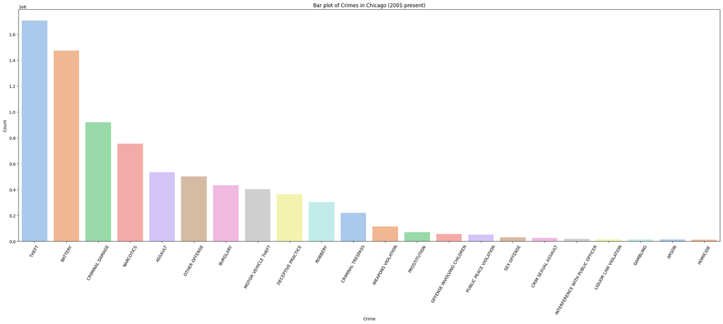

```python
# Considering crimes which are committed >10,000
if crime_type_query_run is True:
    common_crimes=crime_type_results.loc[crime_type_results['count_of_crime_committed']>10000]

    # Bar plot of primary_type
    fig=plt.figure(figsize=(30,10))
    sns.barplot(x='primary_type',y='count_of_crime_committed',hue='primary_type',palette='pastel',data=common_crimes)
    plt.xticks(rotation=60)
    plt.xlabel('Crime')
    plt.ylabel('Count')
    plt.title('Bar plot of Crimes in Chicago (2001-present)')
    plt.show()
```

**Prevalence of Justice of each type of crime in Chicago (2001-present)**

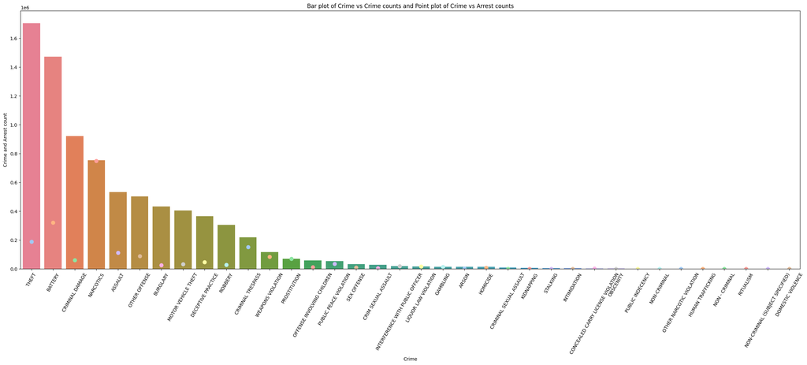

```python
if crime_arrests_query_run is True:
    # Scatter plot for counts_of_crime and arrest_count
    fig=plt.figure(figsize=(30,10))
    sns.barplot(x='primary_type',y='counts_of_crime',hue='primary_type',palette='husl',data=crime_arrests_results)
    sns.pointplot(x='primary_type',y='arrest_count',hue='primary_type',palette='pastel',data=crime_arrests_results)
    plt.xticks(rotation=60)
    plt.xlabel('Crime')
    plt.ylabel('Crime and Arrest count')
    plt.title('Bar plot of Crime vs Crime counts and Point plot of Crime vs Arrest counts')
    plt.show()
```